# Flow Control

Probability and Statistics with R, Second Edition

Last Updated on: Dec 24, 2016 at 13:38:43

# Flow Control

`R`, like most programming languages, has the ability to control the execution of code with programming statements such as `for`, `while`,`repeat`, and `break`. As an example, consider how `for` is used in to add the values 10, 20, and 30.

```r
sum.a <- 0
for(i in c(10, 20, 30)){
  sum.a <- i + sum.a
}
sum.a
```

```
[1] 60
```

The `for` statement allows one to specify that a certain operation will be repeated a fixed number of times. The syntax for the `for` statement is

```
for (name in vector) {
    statements
    }
```

Statements can be grouped using braces `{}`. When several statements are grouped, the standard `R` syntax is to start with a left brace `{`, then place each statement on its own line and close the group of statements with a right brace `}` on its own line.

### Example:

A Lucas number is defined as
$$L_n =
\begin{cases}
2 & \text{if } n =1\\
1 & \text{if } n =2\\
L_{n-1} + L_{n-2} & \text{if } n \geq 3.
\end{cases}$$
Use a `for` loop to compute the first 15 Lucas numbers.

The first 15 Lucas numbers after allocating space using the `numeric()` function for the answers.

```r
Number <- 15              # Number of Lucas numbers desired
Lucas <- numeric(Number)  # Storage for Lucas numbers
Lucas[1] <- 2             # First Lucas number
Lucas[2] <- 1             # Second Lucas number
for(i in 3:Number){
  Lucas[i] <- Lucas[i - 1] + Lucas[i - 2]
}
Lucas
```

```
 [1]   2   1   3   4   7  11  18  29  47  76 123 199 322 521 843
```

The square root of a positive number, $x$, can be approximated iteratively using $x_{n+1} = (x_n + x/x_n)/2$ where $x_n$ is the initial guess for the value of $\sqrt{x}$. Approximating the $\sqrt{113734}$ to within 0.00001 can be accomplished using a `while` statement or a `repeat` statement. Using a `while` statement to approximate $\sqrt{113734}$ to within a 0.00001 is shown below.

```r
options(digits = 8)
x <- 113734
tolerance <- 0.00001
oldapp <- x/2
newapp <- (oldapp + x/oldapp)/2
i <- 0
while( abs(newapp - oldapp) > tolerance){
  oldapp <- newapp
  newapp <- (oldapp + x/oldapp)/2
  i <- i + 1         # Iteration number
}
c(newapp, i)
```

```
[1] 337.24472  11.00000
```

```r
options(digits = 7)  # reset to default
```

Using a `repeat` statement to approximate $\sqrt{113734}$ to within a 0.00001 is shown next.

```r
options(digits = 8)
x <- 113734
tolerance <- 0.00001
oldapp <- x/2
newapp <- (oldapp + x/oldapp)/2
i <- 0
repeat{
  oldapp <- newapp
  newapp <- (oldapp + x/oldapp)/2
  i <- i + 1
  if(abs(newapp - oldapp) < tolerance)
    break
}
c(newapp, i)
```

```
[1] 337.24472  11.00000
```

```r
options(digits = 7) # reset to default
```

The approximate $\sqrt{113734}$ (337.24472) is achieved in $i = 11$ iterations regardless of the type of statement used.

The `if` statement allows one to control which statements are executed. The syntax for the `if` statement has two forms:

```
if (condition) {statements when TRUE}
```

and

```
if (condition) {
statements when TRUE
} else {
statements when FALSE
}
```

One needs to pay close attention to how the second form is typed. In particular, entering

```
if(condition) {statements when TRUE}
else {statements when FALSE}
```

may not do what you expect. `R` will execute the first line before seeing the second line.

### Example:

Write three separate programs to simulate throwing a pair of dice 99,999 times. Compute the mean of each of the 99,999 throws, and create a table of the means using a for loop, a while statement, and a repeat statement.

### Solution:

The function `sample()` is used to sample 2 values with replacement from 1 to 6.

**Using a for loop:** Each time the loop cycles, the mean of the two dice is stored in the $i^{\text{th}}$ position of the `means` vector. The tabled results are stored in `T1` and subsequently printed.

```r
set.seed(3)           # setting seed for reproducibility
N <- 10^5 - 1         # N = number of simulations
means <- numeric(N)   # Defining numeric vector of size N
for(i in 1:N){
  means[i] <- mean(sample(x = 1:6, size = 2, replace = TRUE))
  }
T1 <- table(means)
T1
```

```
means
    1   1.5     2   2.5     3   3.5     4   4.5     5   5.5     6
 2802  5523  8394 11138 13938 16552 13876 11202  8287  5576  2711
```

**Using a while statement:** The command `matrix(0, N, 2)` creates a 99,999 by 2 matrix of zeros. While $i \leq N$, the results from simulating tossing two dice are stored in the $i^\text{th}$ row of the `N2mat` matrix. The function `apply()` is used to compute the mean of each of the rows of `N2mat` and to store the result in the vector `means`. The tabled results are stored in `T2` and subsequently printed.

```r
set.seed(3)                 # setting seed for reproducibility
i <- 1
N <- 10^5 - 1               # N = number of simulations
N2mat <- matrix(0, N, 2)    # initialize N*2 matrix to all 0's
while(i <= N){
  N2mat[i, ] <- sample(x = 1:6, size = 2, replace = TRUE)
  i <- i + 1
}
means <- apply(N2mat, 1, mean)
T2 <- table(means)
T2
```

```
means
    1   1.5     2   2.5     3   3.5     4   4.5     5   5.5     6
 2802  5523  8394 11138 13938 16552 13876 11202  8287  5576  2711
```

**Using a repeat statement:** The line `N2mat[i, ] <- sample(1:6, 2, replace = TRUE)` is repeated, filling in the $i^\text{th}$ row of the matrix with values that simulate throwing two dice until $i = N$, at which point the repeat ends. The function `apply()` is used to compute the mean of each of the rows of `N2mat` and to store the result in the vector `means`. The tabled results are stored in `T3` and subsequently printed.

```r
set.seed(3)                  # setting seed for reproducibility
i <- 1
N <- 10^5 - 1                # N = number of simulations
N2mat <- matrix(0, N, 2)     # initialize N*2 matrix to all 0's
repeat{
  N2mat[i, ] <- sample(1:6, 2, replace = TRUE)
  if (i == N) break
  i <- i + 1
}
means <- apply(N2mat, 1, mean)
T3 <- table(means)
T3
```

```
means
    1   1.5     2   2.5     3   3.5     4   4.5     5   5.5     6
 2802  5523  8394 11138 13938 16552 13876 11202  8287  5576  2711
```

The function `plot()` is applied to `T3` after dividing its contents by `N`.

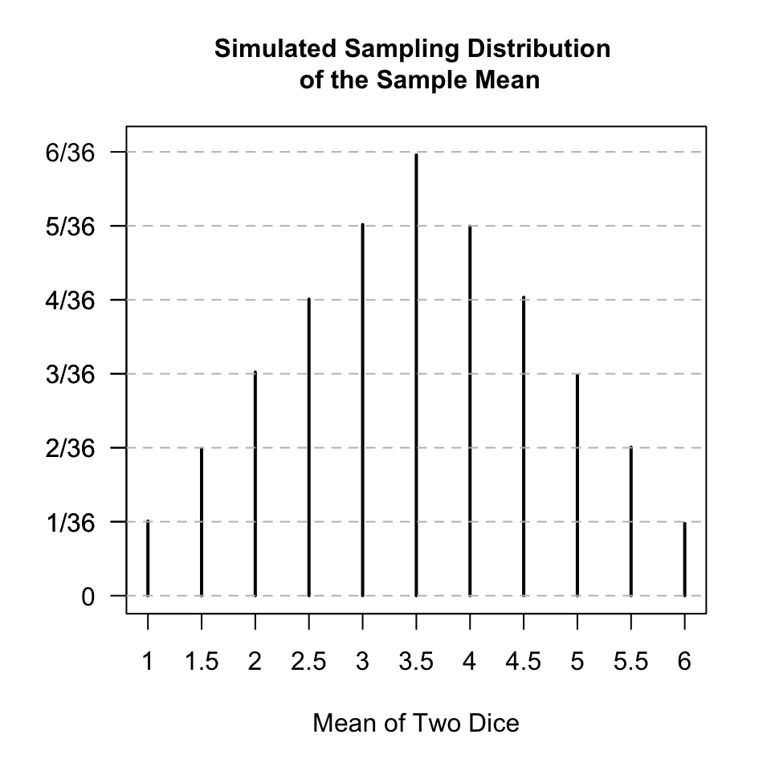

```r
par(yaxt = "n")
plot(T3/N, xlab = "Mean of Two Dice", ylab = "",
     main="Simulated Sampling Distribution \n of the Sample Mean",
     ylim=c(0, 6.1/36), lwd = 2, cex.main = 1)
par(yaxt = "s")
axis(side = 2, at = c(0, 1/36, 2/36, 3/36, 4/36, 5/36, 6/36, 5/36, 4/36, 3/36, 2/36, 1/36),
     labels = c("0","1/36", "2/36", "3/36", "4/36", "5/36", "6/36", "5/36",
              "4/36", "3/36", "2/36", "1/36"), las=1 )
abline(h = c(0:6)/36, lty = 2, col = "gray")
```